# EX3-SNA

Motahhreh Nadimi

4/3/2020

## Exercise 1.1

**Star Network**

```r
library(statnet)
g <- network.initialize(15)
g
```

```
##  Network attributes:
##   vertices = 15
##   directed = TRUE
##   hyper = FALSE
##   loops = FALSE
##   multiple = FALSE
##   bipartite = FALSE
##   total edges= 0
##     missing edges= 0
##     non-missing edges= 0
##
##  Vertex attribute names:
##     vertex.names
##
## No edge attributes
```

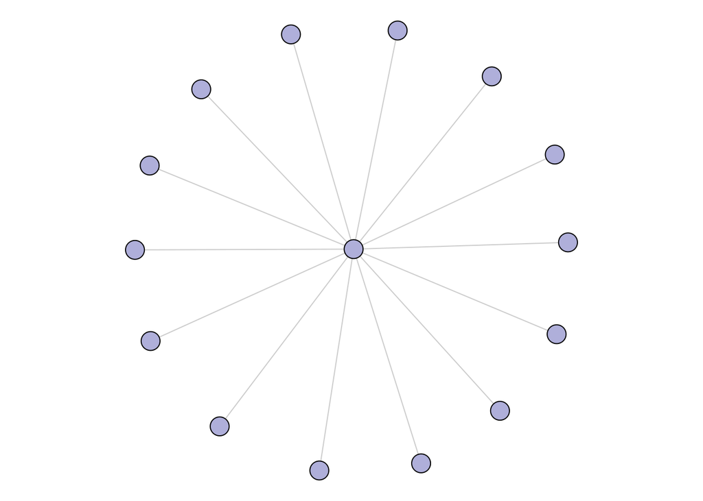

```r
g[1,] <- 1 #Add an edge from 1 to ALL
par(mar=c(0,0,0,0))
gplot(g,gmode="graph",vertex.cex=1,
      vertex.col=rgb(0,0,139,alpha=80,
                     maxColorValue=255),
      edge.col="grey80",edge.lwd=0.02,
       thresh=0.01,jitter=TRUE, usecurve=FALSE)
```

**Complete Network**

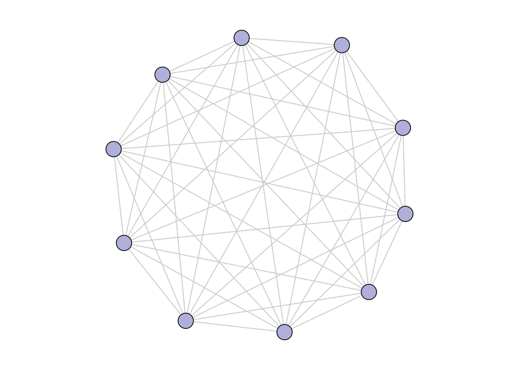

```r
g <- network.initialize(10) #Create an empty graph
g[,] <- 1
par(mar=c(0,0,0,0))
gplot(g,gmode="graph",vertex.cex=1,
      vertex.col=rgb(0,0,139,alpha=80,
                     maxColorValue=255),
      edge.col="grey80",edge.lwd=0.02,
       thresh=0.01,jitter=TRUE, usecurve=FALSE)
```

**Circle Network**

```r
n<-50  #fill the N , N is number of nodes
g <- network.initialize(n) #Create an empty graph
g
```

```
##  Network attributes:
##   vertices = 50
##   directed = TRUE
##   hyper = FALSE
##   loops = FALSE
##   multiple = FALSE
##   bipartite = FALSE
##   total edges= 0
##     missing edges= 0
##     non-missing edges= 0
##
##  Vertex attribute names:
##     vertex.names
##
## No edge attributes
```

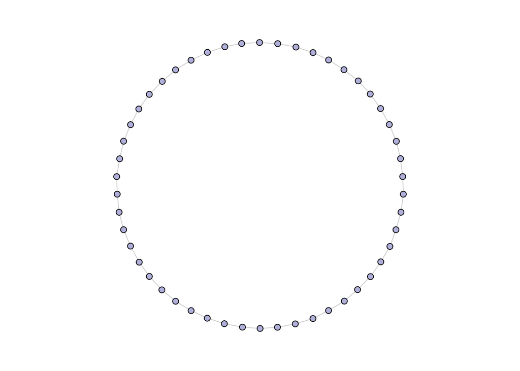

```r
mat<-as.sociomatrix(g)
#mat
mat[row(mat) == col(mat)-1] <-mat[n,1] <- 1 # change entries
#mat
g[,]<-mat # using replacement operators
#summary(g)
#g[1,2] <- g[2,3] <- g[3,4] <- g[4,5] <-g[5,1] <- 1
par(mar=c(0,0,0,0))
gplot(g,gmode="graph",vertex.cex=0.6,
      vertex.col=rgb(0,0,139,alpha=80,
                     maxColorValue=255),
      edge.col="grey80",edge.lwd=0.02,
      thresh=0.01,jitter=TRUE, usecurve=FALSE,mode='circle')
```

**Line network**

```r
n<-30  #fill the N , N is number of nodes
g <- network.initialize(n) #Create an empty graph
g
```

```
##  Network attributes:
##   vertices = 30
##   directed = TRUE
##   hyper = FALSE
##   loops = FALSE
##   multiple = FALSE
##   bipartite = FALSE
##   total edges= 0
##     missing edges= 0
##     non-missing edges= 0
##
##  Vertex attribute names:
##     vertex.names
##
## No edge attributes
```

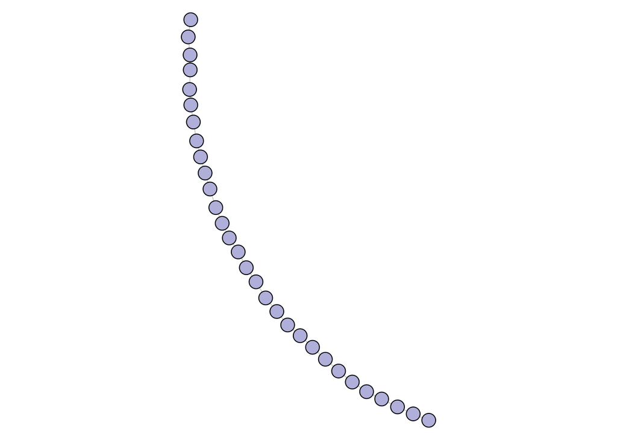

```r
mat<-as.sociomatrix(g)
#mat
mat[row(mat) == col(mat)-1] <- 1 # change entries
#mat
g[,]<-mat # using replacement operators
#summary(g)
#g[1,2] <- g[2,3] <- g[3,4] <- g[4,5] <-g[5,1] <- 1
par(mar=c(0,0,0,0))
gplot(g,gmode="graph",vertex.cex=1,
      vertex.col=rgb(0,0,139,alpha=80,
                     maxColorValue=255),
      edge.col="grey80",edge.lwd=0.02,
       thresh=0.01,jitter=TRUE, usecurve=FALSE,mode='kamadakawai')
```

## Exercise 1.2

**a) write a R function for each type of graph allowing the user to generate graphs with an arbitrary number of nodes. b) Running the above R functions to show the adjacency matrix of each type of graph having not less than 100 nodes. NOTE: Graphs must be stored as R objects of class “network”**

**Complete Graph**

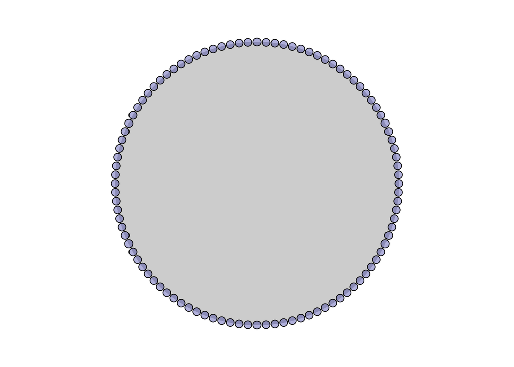

```
##  Network attributes:
##   vertices = 100
##   directed = TRUE
##   hyper = FALSE
##   loops = FALSE
##   multiple = FALSE
##   bipartite = FALSE
##   total edges= 19800
##     missing edges= 0
##     non-missing edges= 19800
##
##  Vertex attribute names:
##     vertex.names
##
##  Edge attribute names not shown
```

```r
n<- 100 # n is # of nodes
randomG <- rgraph(n, m=1, tprob=1, mode="digraph") # Create a random graph with n=7 nodes and tie prob = 0.5
generate <- function(randomG) {
  output <-as.network(randomG)
  add.edges(output,row(randomG)[randomG>0],col(randomG)[randomG>0])
  par(mar=c(0,0,0,0))
  gplot(output,gmode="graph",vertex.cex=1,
        vertex.col=rgb(0,0,139,alpha=80,
                       maxColorValue=255),
        edge.col="grey80",edge.lwd=0.02,
         thresh=0.01,jitter=TRUE, usecurve=FALSE,mode = 'circle')
  return(output)
}
generate(randomG)
```

```r
d<-as.sociomatrix(randomG) #showing the adjecncy matrix
d[1:10,1:10]
```

```
##       [,1] [,2] [,3] [,4] [,5] [,6] [,7] [,8] [,9] [,10]
##  [1,]    0    1    1    1    1    1    1    1    1     1
##  [2,]    1    0    1    1    1    1    1    1    1     1
##  [3,]    1    1    0    1    1    1    1    1    1     1
##  [4,]    1    1    1    0    1    1    1    1    1     1
##  [5,]    1    1    1    1    0    1    1    1    1     1
##  [6,]    1    1    1    1    1    0    1    1    1     1
##  [7,]    1    1    1    1    1    1    0    1    1     1
##  [8,]    1    1    1    1    1    1    1    0    1     1
##  [9,]    1    1    1    1    1    1    1    1    0     1
## [10,]    1    1    1    1    1    1    1    1    1     0
```

```r
output <-as.network(randomG)
```

**star graph**

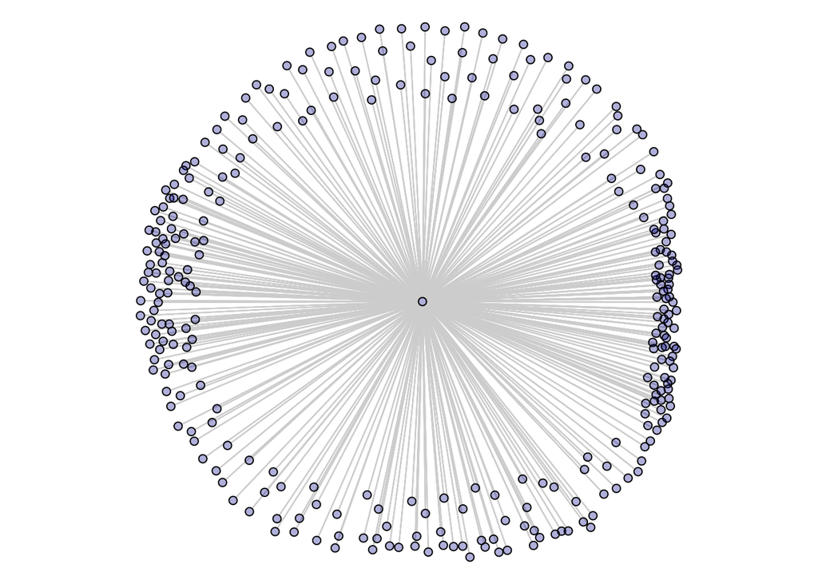

```
##  Network attributes:
##   vertices = 300
##   directed = TRUE
##   hyper = FALSE
##   loops = FALSE
##   multiple = FALSE
##   bipartite = FALSE
##   total edges= 1197
##     missing edges= 0
##     non-missing edges= 1197
##
##  Vertex attribute names:
##     vertex.names
##
##  Edge attribute names not shown
```

```r
n<-300 # fill the n
randomG <- rgraph(n, m=1, tprob=0, mode="graph") # Create a random graph with n=7 nodes and tie prob = 0.5
randomG[,1] <-randomG[1,] <- 1
generate <- function(randomG) {
  output <-as.network(randomG)
  add.edges(output,row(randomG)[randomG>0],col(randomG)[randomG>0])
  par(mar=c(0,0,0,0))
  gplot(output,gmode="graph",vertex.cex=1,
        vertex.col=rgb(0,0,139,alpha=80,
                       maxColorValue=255),
        edge.col="grey80",edge.lwd=0.02,
         thresh=0.01,jitter=TRUE, usecurve=FALSE)
  return(output)
}
generate(randomG)
```

```r
d<-as.sociomatrix(randomG) #showing the adjecncy matrix
d[1:10,1:10]
```

```
##       [,1] [,2] [,3] [,4] [,5] [,6] [,7] [,8] [,9] [,10]
##  [1,]    1    1    1    1    1    1    1    1    1     1
##  [2,]    1    0    0    0    0    0    0    0    0     0
##  [3,]    1    0    0    0    0    0    0    0    0     0
##  [4,]    1    0    0    0    0    0    0    0    0     0
##  [5,]    1    0    0    0    0    0    0    0    0     0
##  [6,]    1    0    0    0    0    0    0    0    0     0
##  [7,]    1    0    0    0    0    0    0    0    0     0
##  [8,]    1    0    0    0    0    0    0    0    0     0
##  [9,]    1    0    0    0    0    0    0    0    0     0
## [10,]    1    0    0    0    0    0    0    0    0     0
```

**Circle graph or ring graph**

```r
n<- 100
m <- rgraph(n, m=1, tprob=0, mode="graph")
m[row(m) == col(m)-1] <-m[n,1] <- 1 # change entries
m[1:5,1:5]
```

```
##      [,1] [,2] [,3] [,4] [,5]
## [1,]    0    1    0    0    0
## [2,]    0    0    1    0    0
## [3,]    0    0    0    1    0
## [4,]    0    0    0    0    1
## [5,]    0    0    0    0    0
```

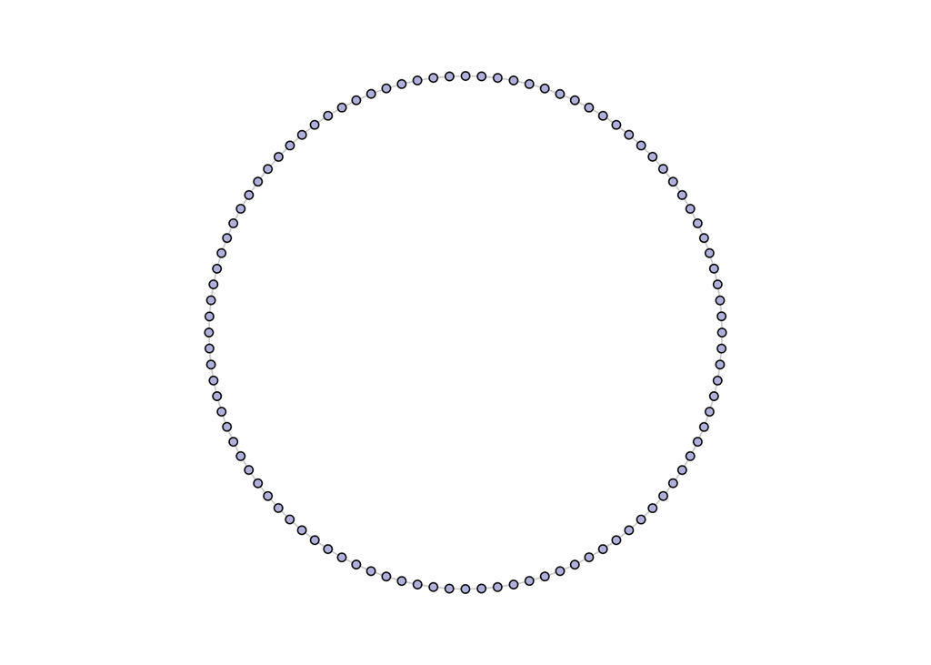

```
##  Network attributes:
##   vertices = 100
##   directed = TRUE
##   hyper = FALSE
##   loops = FALSE
##   multiple = FALSE
##   bipartite = FALSE
##   total edges= 200
##     missing edges= 0
##     non-missing edges= 200
##
##  Vertex attribute names:
##     vertex.names
##
## No edge attributes
```

```r
generate <- function(m) {
  output <-as.network(m)
  add.edges(output,row(m)[m>0],col(m)[m>0])
  par(mar=c(0,0,0,0))
  gplot(output,gmode="graph",vertex.cex=0.6,
        vertex.col=rgb(0,0,139,alpha=80,
                       maxColorValue=255),
        edge.col="grey80",edge.lwd=0.02,
         thresh=0.01,jitter=TRUE, usecurve=FALSE, mode = 'circle')
  return(output)
}
generate(m)
```

```r
d<-as.sociomatrix(randomG) #showing the adjecncy matrix
d[1:10,1:10]
```

[output not shown]

**line graph**

```r
#.................................................
n<- 100
m <- rgraph(n, m=1, tprob=0, mode="graph")
m[row(m) == col(m)-1] <- 1 # change entries
m[1:5,1:5]
```

```
##      [,1] [,2] [,3] [,4] [,5]
## [1,]    0    1    0    0    0
## [2,]    0    0    1    0    0
## [3,]    0    0    0    1    0
## [4,]    0    0    0    0    1
## [5,]    0    0    0    0    0
```

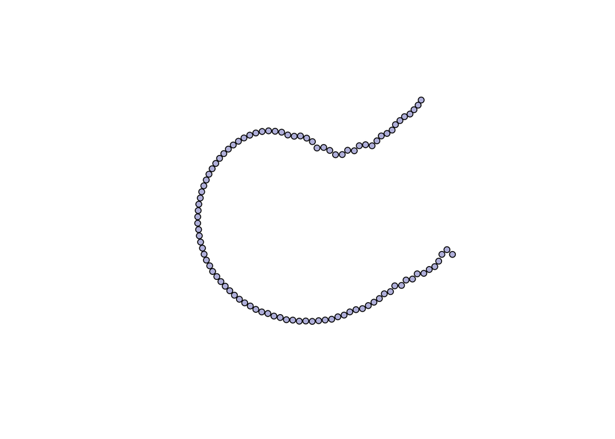

```
##  Network attributes:
##   vertices = 100
##   directed = TRUE
##   hyper = FALSE
##   loops = FALSE
##   multiple = FALSE
##   bipartite = FALSE
##   total edges= 198
##     missing edges= 0
##     non-missing edges= 198
##
##  Vertex attribute names:
##     vertex.names
##
## No edge attributes
```

```r
generate <- function(m) {
  output <-as.network(m)
  add.edges(output,row(m)[m>0],col(m)[m>0])
  gplot(output,gmode="graph",vertex.cex=1,
        vertex.col=rgb(0,0,139,alpha=80,
                       maxColorValue=255),
        edge.col="grey80",edge.lwd=0.02,
       thresh=0.01,jitter=TRUE, usecurve=FALSE,mode='kamadakawai')
  return(output)
}
generate(m)
```

```r
d<-as.sociomatrix(randomG) #showing the adjecncy matrix
d[1:10,1:10]
```

[output not shown]

## Exercise 2.1

**Generate a directed cyclic circle graph of the same size of the circle graph created in exercise 1. (again this should be stored in an object of network class)**

**try with 10 nodes**

```r
n<-10
m <- rgraph(n, m=1, tprob=0, mode="digraph")
m[1:5,1:5]
```

```
##      [,1] [,2] [,3] [,4] [,5]
## [1,]    0    0    0    0    0
## [2,]    0    0    0    0    0
## [3,]    0    0    0    0    0
## [4,]    0    0    0    0    0
## [5,]    0    0    0    0    0
```

```r
m[row(m) == col(m)-1] <-m[n,1] <- 1 # change entries
m[5,2]<-m[2,4]<-m[4,5] <- 1 # change entries
m[9,4]<-m[4,7]<-m[7,9] <- 1 # change entries

m
```

```
##       [,1] [,2] [,3] [,4] [,5] [,6] [,7] [,8] [,9] [,10]
##  [1,]    0    1    0    0    0    0    0    0    0     0
##  [2,]    0    0    1    1    0    0    0    0    0     0
##  [3,]    0    0    0    1    0    0    0    0    0     0
##  [4,]    0    0    0    0    1    0    1    0    0     0
##  [5,]    0    1    0    0    0    1    0    0    0     0
##  [6,]    0    0    0    0    0    0    1    0    0     0
##  [7,]    0    0    0    0    0    0    0    1    1     0
##  [8,]    0    0    0    0    0    0    0    0    1     0
##  [9,]    0    0    0    1    0    0    0    0    0     1
## [10,]    1    0    0    0    0    0    0    0    0     0
```

```r
g <- network(m, directed=TRUE,loops=TRUE,matrix.type="adjacency")
summary(g)
```

```
## Network attributes:
##   vertices = 10
##   directed = TRUE
##   hyper = FALSE
##   loops = TRUE
##   multiple = FALSE
##   bipartite = FALSE
##  total edges = 15
##    missing edges = 0
##    non-missing edges = 15
##  density = 0.15
##
## Vertex attributes:
##   vertex.names:
##    character valued attribute
##    10 valid vertex names
##
## No edge attributes
##
## Network adjacency matrix:
##    1 2 3 4 5 6 7 8 9 10
## 1  0 1 0 0 0 0 0 0 0  0
## 2  0 0 1 1 0 0 0 0 0  0
## 3  0 0 0 1 0 0 0 0 0  0
## 4  0 0 0 0 1 0 1 0 0  0
## 5  0 1 0 0 0 1 0 0 0  0
## 6  0 0 0 0 0 0 1 0 0  0
## 7  0 0 0 0 0 0 0 1 1  0
## 8  0 0 0 0 0 0 0 0 1  0
## 9  0 0 0 1 0 0 0 0 0  1
## 10 1 0 0 0 0 0 0 0 0  0
```

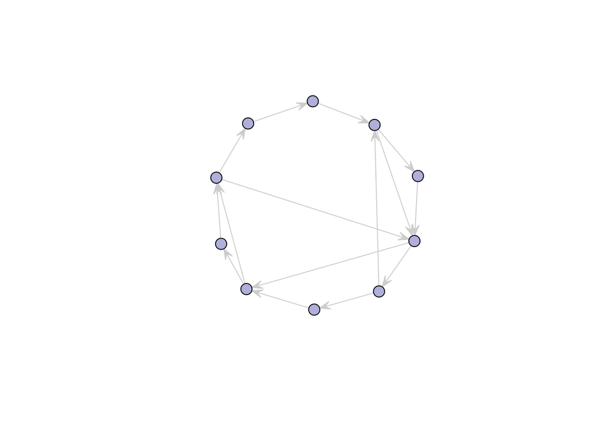

```r
gplot(g,gmode="digraph",vertex.cex=1,
      vertex.col=rgb(0,0,139,alpha=80,
                     maxColorValue=255),
      edge.col="grey80",edge.lwd=0.02,
     thresh=0.01,jitter=TRUE, usecurve=FALSE,mode='circle')
```

**code with 100 nodes**

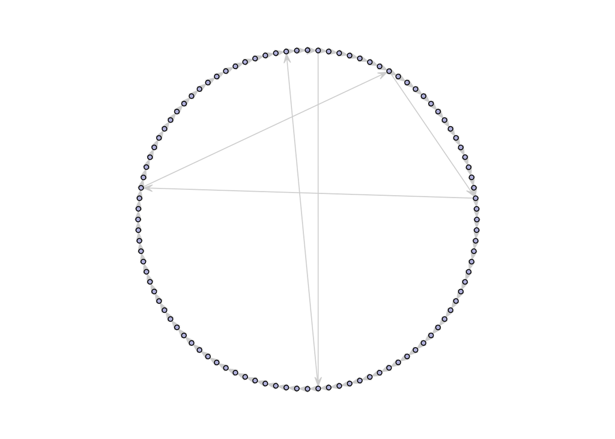

```r
n<-100
m <- rgraph(n, m=1, tprob=0, mode="digraph")
m[row(m) == col(m)-1] <-m[n,1] <- 1 # change entries
m[99,2]<-m[2,50]<-m[50,99] <- 1 # change entries
m[9,24]<-m[24,79]<-m[79,9] <- 1 # change entries
g <- network(m, directed=TRUE,loops=TRUE,matrix.type="adjacency")
#summary(g)

par(mar=c(0,0,0,0))

gplot(g,gmode="digraph",vertex.cex=0.5,
      vertex.col=rgb(0,0,139,alpha=80,
                     maxColorValue=255),
      edge.col="grey80",edge.lwd=0.02,
       thresh=0.01,jitter=TRUE, usecurve=FALSE,mode='circle')
```